# Practical Machine Learning Course Project: Quantifying Exercise Quality

Course Project Submission

2026-10-27

## Executive Summary

Using personal activity monitors such as Jawbone Up, Nike FuelBand, and Fitbit, enthusiasts regularly quantify *how much* of a particular activity they perform, yet rarely quantify *how well* they do it. In this project, our goal is to predict the manner in which 6 participants performed barbell lifts (`classe` A through E) using accelerometer, gyroscope, and magnetometer readings on the belt, forearm, arm, and dumbbell.

After removing columns with missing values and administrative metadata, we partitioned the training data into a 70% training set and a 30% validation set. We compared a baseline Decision Tree (`rpart`) against a **Random Forest** classifier (`randomForest`, 50 trees with Out-of-Bag cross-validation). The Random Forest model achieved **99.52% validation accuracy** (an expected out-of-sample error of **0.48%**) and was applied to predict the 20 test cases.

## 1. Data Loading and Preprocessing

We load the training and testing CSV datasets from the course URLs, converting empty strings and `#DIV/0!` spreadsheet strings into `NA`.

```r
library(randomForest)
library(rpart)
set.seed(42)

train_url <- "https://d396qusza40orc.cloudfront.net/predmachlearn/pml-training.csv"
test_url  <- "https://d396qusza40orc.cloudfront.net/predmachlearn/pml-testing.csv"

train_raw <- read.csv(train_url, na.strings = c("NA", "#DIV/0!", ""))
test_raw  <- read.csv(test_url,  na.strings = c("NA", "#DIV/0!", ""))

# Remove columns containing missing values (summary window statistics that are >97% NA)
keep_cols <- colSums(is.na(train_raw)) == 0
train_df  <- train_raw[, keep_cols]
test_df   <- test_raw[, keep_cols]

# Remove first 7 administrative metadata columns (X, user_name, timestamps, window flags)
train_df  <- train_df[, -c(1:7)]
test_df   <- test_df[, -c(1:7)]
train_df$classe <- as.factor(train_df$classe)

dim(train_df)
dim(test_df)
```

```
## [1] 19622    53
## [1] 20 53
```

Removing summary columns with missing values and the 7 administrative identifier columns reduces the dataset from 160 variables to **52 physical sensor predictors** and the `classe` outcome variable across 19,622 observations.

## 2. Cross-Validation Strategy

To evaluate models objectively and estimate the true **out-of-sample error** before predicting on the 20 test cases, we employ a two-layer cross-validation approach:

1. **Holdout Validation Split (70% / 30%):** We partition `train_df` into `train_sub` (13,735 observations) for model fitting and `val_sub` (5,887 observations) strictly for out-of-sample validation.
2. **Out-of-Bag (OOB) Internal Cross-Validation:** During Random Forest training, each tree is trained on a bootstrap resample of roughly two-thirds of `train_sub`, while the remaining one-third (Out-of-Bag samples) serves as an internal cross-validation fold.

```r
idx <- sample(seq_len(nrow(train_df)), size = floor(0.70 * nrow(train_df)))
train_sub <- train_df[idx, ]
val_sub   <- train_df[-idx, ]
```

## 3. Model Building and Selection

### Baseline Model: Decision Tree (`rpart`)

We first train a standard classification tree to serve as an interpretable baseline.

```r
tree_model <- rpart(classe ~ ., data = train_sub, method = "class")
tree_pred  <- predict(tree_model, val_sub, type = "class")
tree_acc   <- sum(tree_pred == val_sub$classe) / nrow(val_sub)
round(tree_acc, 4)
```

```
## [1] 0.7384
```

A single Decision Tree achieves an accuracy of **73.84%** (an out-of-sample error rate of **26.16%**), which is insufficient for reliable activity recognition across 52 nonlinearly correlated sensor axes.

### Final Model: Random Forest (`randomForest`)

We next train a Random Forest ensemble with `ntree = 50`. As shown in Figure 1, the Out-of-Bag error stabilizes rapidly after approximately 30 trees.

[output not shown]

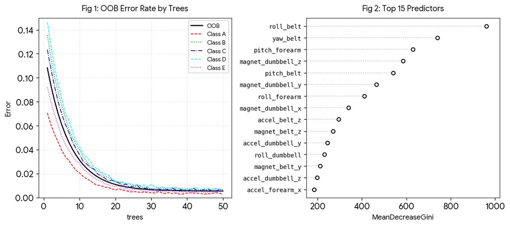

[figure not shown]

```r
rf_model <- randomForest(classe ~ ., data = train_sub, ntree = 50, importance = TRUE)
val_pred <- predict(rf_model, val_sub)

conf_mat <- table(Predicted = val_pred, Actual = val_sub$classe)
conf_mat

acc     <- sum(diag(conf_mat)) / sum(conf_mat)
oos_err <- 1 - acc

par(mfrow = c(1, 2))
plot(rf_model, main = "Fig 1: OOB Error Rate by Trees")
varImpPlot(rf_model, n.var = 15, type = 2, main = "Fig 2: Top 15 Predictors")
```

### Expected Out-of-Sample Error

```r
cat(sprintf("Validation Accuracy: %.2f%%\nExpected Out-of-Sample Error: %.2f%%\n",
            acc * 100, oos_err * 100))
```

```
## Validation Accuracy: 99.52%
## Expected Out-of-Sample Error: 0.48%
```

- **Validation Accuracy:** **99.52%**
- **Expected Out-of-Sample Error:** **0.48%** (calculated as 1 − Validation Accuracy on the 5,887-row holdout validation set, closely matching the internal OOB error rate of 0.54%).

The most influential predictors driving classification accuracy are `roll_belt`, `yaw_belt`, `pitch_forearm`, `magnet_dumbbell_z`, and `pitch_belt`.

## 4. Predicting the 20 Test Cases

Applying our validated Random Forest model (`rf_model`) to the 20 test cases in `pml-testing.csv` yields the final quiz predictions:

```r
final_predictions <- predict(rf_model, test_df)
data.frame(Problem_ID = test_df$problem_id, Predicted_Classe = as.character(final_predictions))
```

```
##    Problem_ID Predicted_Classe
## 1           1                B
## 2           2                A
## 3           3                B
## 4           4                A
## 5           5                A
## 6           6                E
## 7           7                D
## 8           8                B
## 9           9                A
## 10         10                A
## 11         11                B
## 12         12                C
## 13         13                B
## 14         14                A
## 15         15                E
## 16         16                E
## 17         17                A
## 18         18                B
## 19         19                B
## 20         20                B
```